# P&S-2022: Lab assignment 2

### Task 3.

#### First, generate samples an sample means:

```r
id <- 26
nu1 <- id + 10
K <- 1e3
n <- 5
sample_means <- colMeans(matrix(rexp(n*K, rate = nu1), nrow=n))
sample_means
```

[output not shown]

[output cut: 152 more lines]

#### Next, calculate the parameters of the standard normal approximation

```r
mu <- 1/nu1
sigma <- 1/(nu1*sqrt(n))
```

#### We can now plot ecdf and cdf

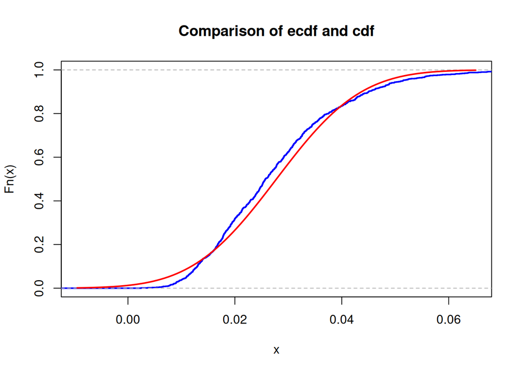

```r
xlims <- c(mu-3*sigma,mu+3*sigma)
Fs <- ecdf(sample_means)
plot(Fs,
     xlim = xlims,
     col = "blue",
     lwd = 2,
     main = "Comparison of ecdf and cdf")
curve(pnorm(x, mean = mu, sd = sigma), col = "red", lwd = 2, add = TRUE)
```

#### The maximal difference between the two c.d.f.’s;

```r
max_diff <- max(abs(Fs(sample_means)-pnorm(sample_means, mean = mu, sd = sigma)))
max_diff
```

```
## [1] 0.0667864
```

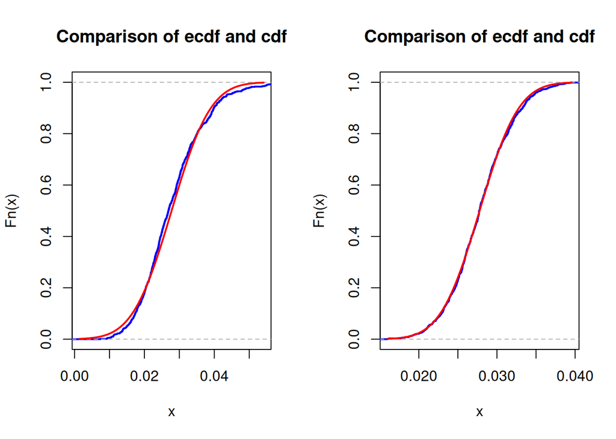

```r
n_values <- c(10, 50)
max_differences <- numeric(length(n_values))

par(mfrow=c(1, length(n_values)))

for (i in seq_along(n_values)) {
  n <- n_values[i]

  sample_means <- colMeans(matrix(rexp(n*K, rate = nu1), nrow=n))

  mu <- 1/nu1
  sigma <- 1/(nu1*sqrt(n))

  Fs <- ecdf(sample_means)

  x_vals <- sort(sample_means)

  max_differences[i] <- max(abs(Fs(x_vals) - pnorm(x_vals, mean = mu, sd = sigma)))

  xlims <- c(mu-3*sigma, mu+3*sigma)
  plot(Fs,
     xlim = xlims,
     col = "blue",
     lwd = 2,
     main = "Comparison of ecdf and cdf")
  curve(pnorm(x, mean = mu, sd = sigma), col = "red", lwd = 2, add = TRUE)
}
```

```r
max_differences
```

```
## [1] 0.04685173 0.02021225
```

Based on the simulation results, we can conclude that the distribution of the sample mean of exponential random variables becomes increasingly close to the normal distribution as the sample size grows, which confirms the Central Limit Theorem (CLT). For larger samples (n = 50), the empirical distribution of the sample means is almost indistinguishable from the corresponding normal distribution with mean μ = 1/ν and variance σ² = 1/(nν²). The maximal difference between the empirical cumulative distribution function (ECDF) and the theoretical normal CDF decreases as n increases.

#### Let’s obtain the theoretical bounds on N using the Markov inequality, Chernoff bound and Central Limit Theorem

```r
nu <- N * nu1
p_safe <- 0.95
clicks <- 100
k_clicks <- clicks + 1
T_safe <- 1

nu_markov_max <- (1 - p_safe) * k_clicks / T_safe
N_markov <- nu_markov_max / nu1
cat("Markov bound on N:", N_markov, "\n")
```

```
## Markov bound on N: 0.1402778
```

```r
z_0_05 <- qnorm(1 - p_safe)
nu_clt_max <- k_clicks + z_0_05 * sqrt(k_clicks)
N_clt <- nu_clt_max / nu1
cat("CLT bound on N:", N_clt, "\n")
```

```
## CLT bound on N: 2.346373
```

```r
chernoff_log_equation <- function(nu_val) {
  k_clicks * log(nu_val / k_clicks) + k_clicks - nu_val - log(1 - p_safe)
}

nu_chernoff_max <- tryCatch({
  uniroot(chernoff_log_equation, interval = c(k_clicks * 0.7, k_clicks * 1.3))$root
}, error = function(e) {
  k_clicks - sqrt(2 * k_clicks * abs(log(1 - p_safe)))
})

N_chernoff <- nu_chernoff_max / nu1
cat("Chernoff bound on N:", N_chernoff, "\n")
```

```
## Chernoff bound on N: 2.122235
```

```r
simulate_S <- function(N, K) {
  nu <- N * nu1

  s <- replicate(K, sum(rexp(k_clicks, rate = nu)))

  p_empirical <- mean(s >= T_safe)
  return(list(sums = s, p_safe_empirical = p_empirical))
}

res_markov <- simulate_S(N_markov, K)
res_clt <- simulate_S(N_clt, K)
res_chernoff <- simulate_S(N_chernoff, K)

cat("Markov      ", N_markov, "  ", res_markov$p_safe_empirical, "\n")
```

```
## Markov       0.1402778    1
```

```r
cat("CLT         ", N_clt, "   ", res_clt$p_safe_empirical, "\n")
```

```
## CLT          2.346373     0.958
```

```r
cat("Chernoff    ", N_chernoff, "   ", res_chernoff$p_safe_empirical, "\n")
```

```
## Chernoff     2.122235     0.997
```

The results show that the three bounds — Markov, CLT, and Chernoff — give quite different estimates for the maximal number of radioactive samples N that can be safely stored.

The Markov inequality only uses the expected value of the total time between clicks and ignores any information about the variance or shape of the distribution. Because of this, it provides only a very loose upper bound, ensuring safety with almost absolute certainty (probability ≈ 1).

The CLT bound (N ≈ 2.35) uses the Central Limit Theorem approximation, which takes into account both the mean and variance of the total time between clicks. This provides a much more realistic estimate, corresponding to a safety probability close to the desired 0.95. It reflects the fact that as the number of clicks increases, the sum of exponential random variables behaves approximately normally, giving a tighter and more accurate bound.